# tennis

Mihai Matei, Catalin Stefan Cernat 511DS

3/24/2021

## ATP Tennis Visualisation

This project is about tennis ATP results

#### Merging ATP and WTA matches CVS files

#### Merging ATP and WTA player CSV files

#### Merging ATP and WTA rankings CSV files

#### Load Country Codes CSV file

### EDA

#### Number of matches per year

Visualize how the number of matcher per league evoluted along each year. Notice the impact of the coronavirul pandemy.

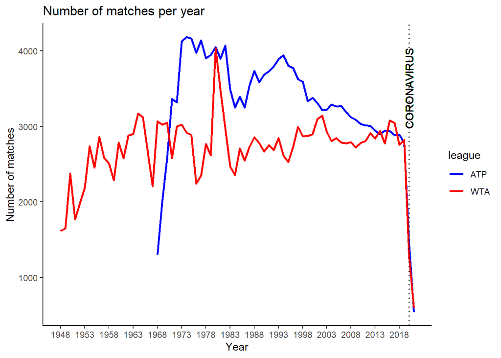

#### Player hand statistics

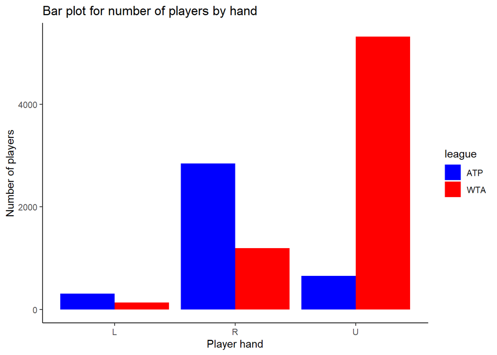

Visualize how many matches are played per league depending on backhand

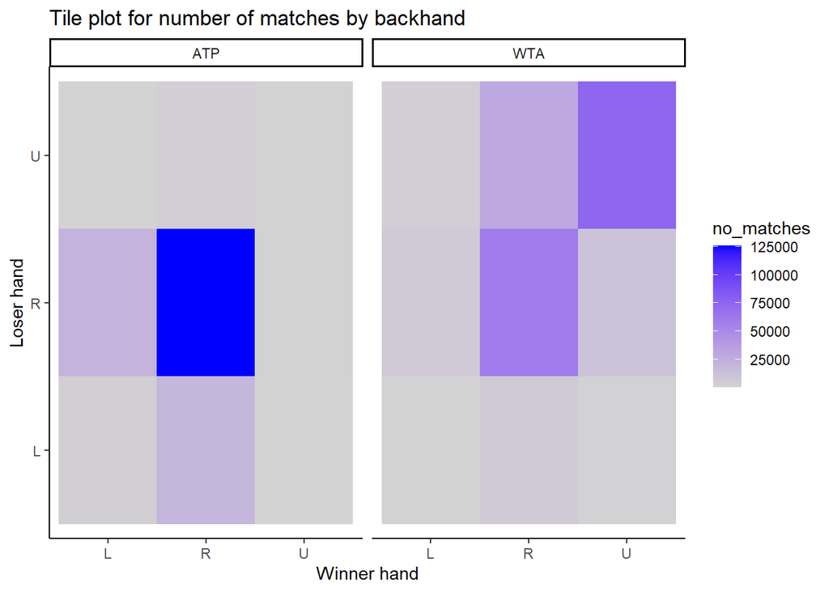

#### Round statistics

Visualize the average match length by round type

[figure not shown]

#### Rank difference

Visualize the average rank by player age

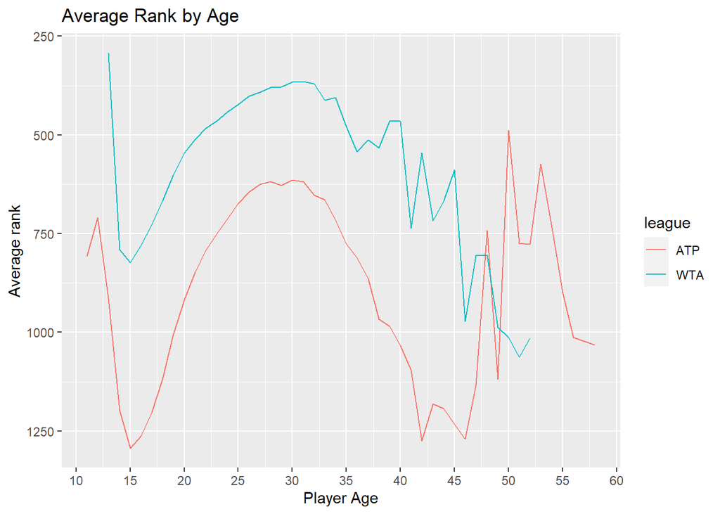

Visualize the average rank by player age (only looking at top 20)

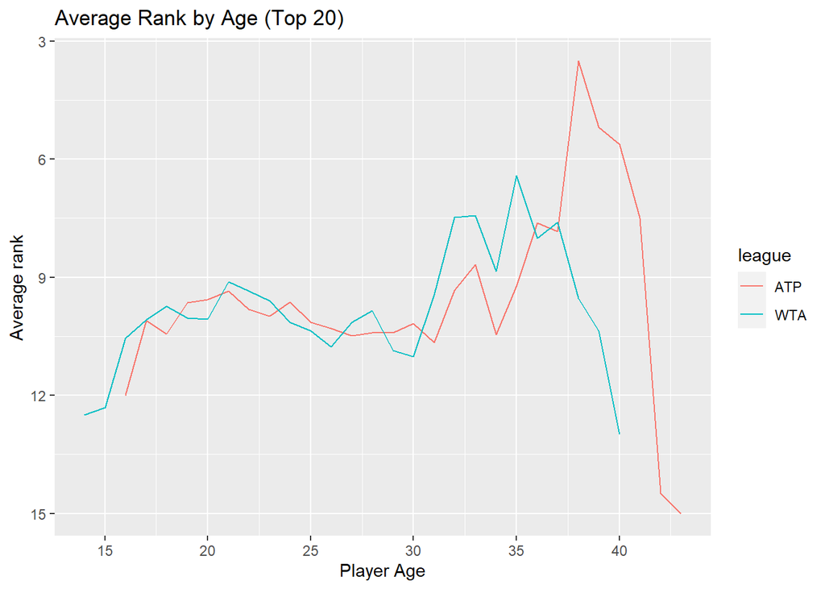

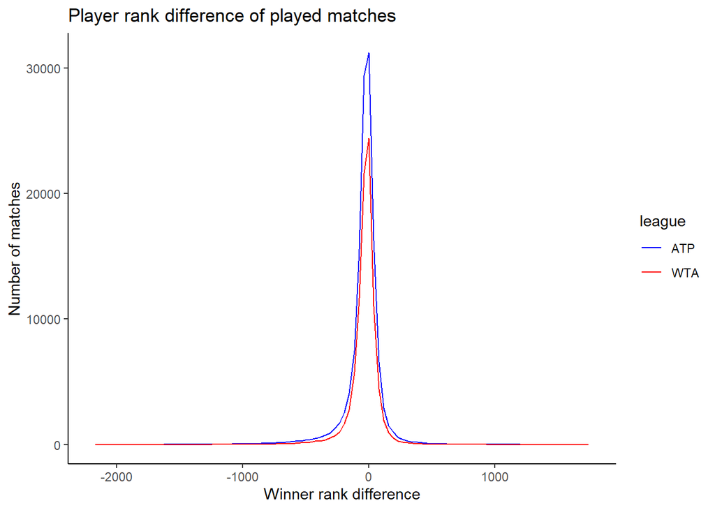

#### Serve statistics

Visualize the percentage of serves won if 1st serve is inside the court (How strong players 1st serve is)

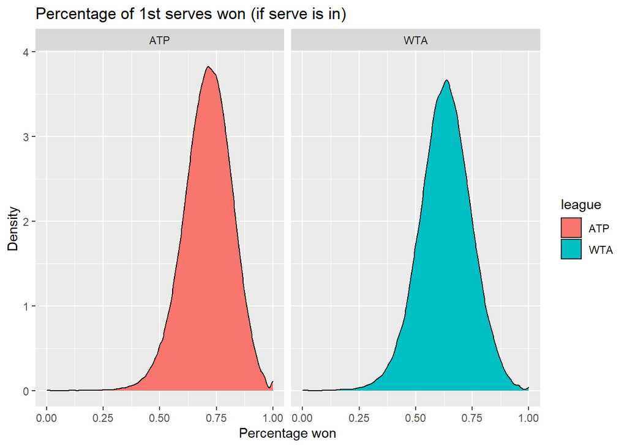

Correlation between serves and breaks with match wins

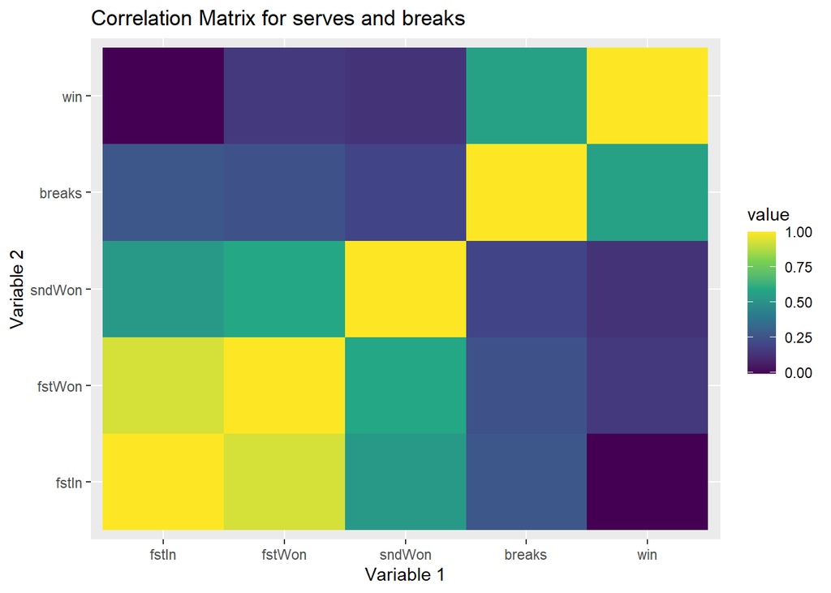

#### Tourney statistics

Plot the top tourney matches player per year

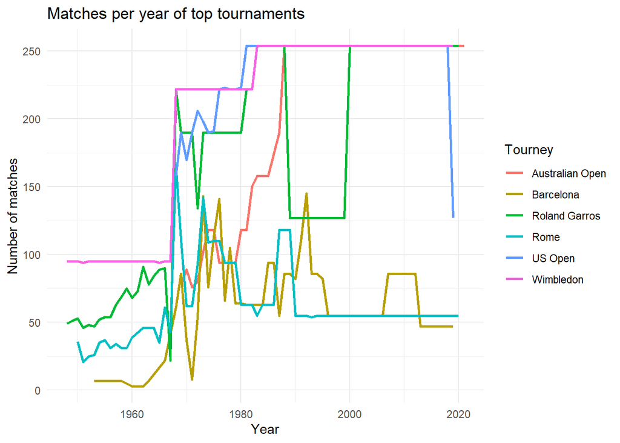

Plot the location on the map of the tourneys. Get the latitude and coordonates from tourney name using openstreetmap

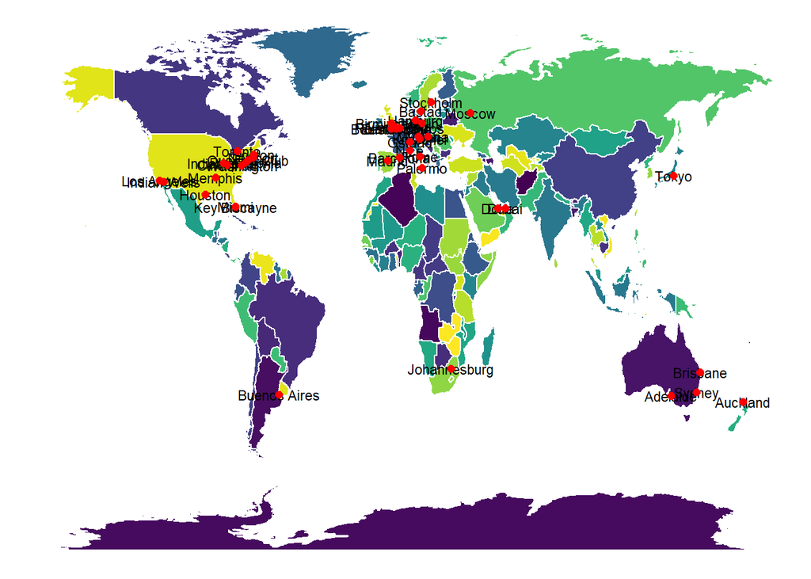

Plot top 10 countries by number of Grand Slams won for ATP and WTA

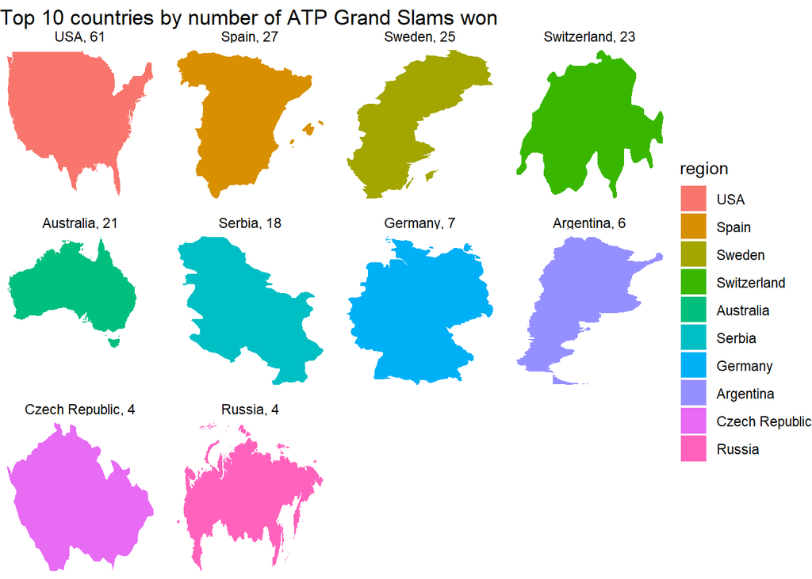

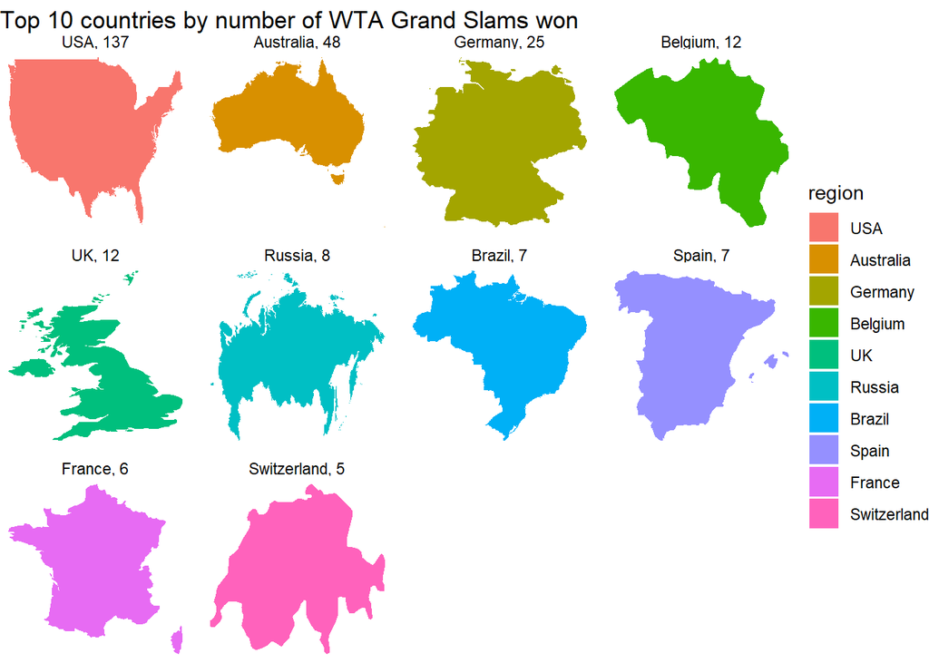

Shiny applications not supported in static R Markdown documents

### Classification models for predicting who will win a match

[output not shown]

[output not shown]

[output not shown]

```
## k-Nearest Neighbors
##
## 11755 samples, 5821 used for final model
##    10 predictor
##     2 classes: '-1', '1'
##
## Pre-processing: centered (10), scaled (10)
## Resampling: Bootstrapped (1 reps)
## Summary of sample sizes: 5934
## Resampling results across tuning parameters:
##
##   k   Accuracy   Kappa
##    3  0.5852946  0.1705881
##    5  0.5923381  0.1846772
##    7  0.5968047  0.1936113
##    9  0.6000687  0.2001422
##   11  0.5993815  0.1987670
##   13  0.5966329  0.1932694
##
## Accuracy was used to select the optimal model using the largest value.
## The final value used for the model was k = 9.
```

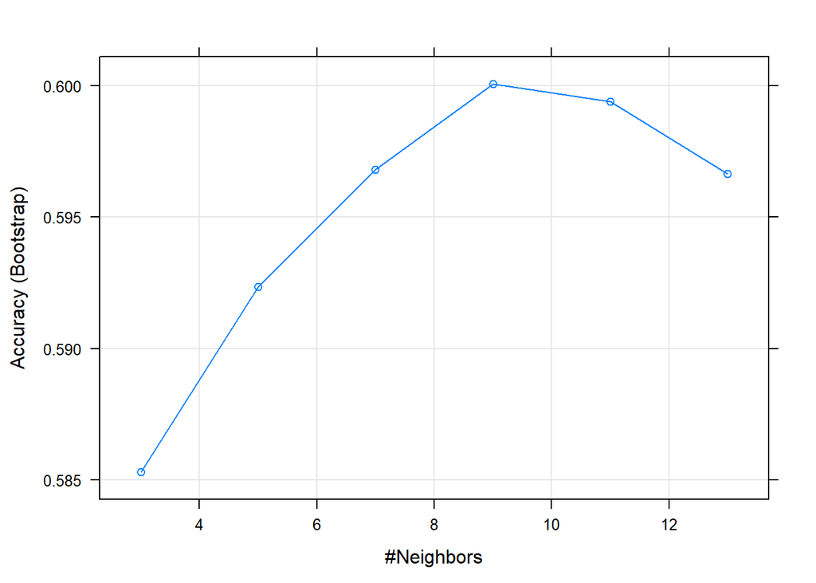

```
## Confusion Matrix and Statistics
##
##           Reference
## Prediction   -1    1
##         -1 1555 1051
##         1  1158 1662
##
##                Accuracy : 0.5929
##                  95% CI : (0.5797, 0.606)
##     No Information Rate : 0.5
##     P-Value [Acc > NIR] : < 2e-16
##
##                   Kappa : 0.1858
##
##  Mcnemar's Test P-Value : 0.02411
##
##             Sensitivity : 0.5732
##             Specificity : 0.6126
##          Pos Pred Value : 0.5967
##          Neg Pred Value : 0.5894
##              Prevalence : 0.5000
##          Detection Rate : 0.2866
##    Detection Prevalence : 0.4803
##       Balanced Accuracy : 0.5929
##
##        'Positive' Class : -1
##
```

```
## Random Forest
##
## 11755 samples, 5821 used for final model
##    10 predictor
##     2 classes: '-1', '1'
##
## No pre-processing
## Resampling: Bootstrapped (1 reps)
## Summary of sample sizes: 5934
## Resampling results across tuning parameters:
##
##   mtry  Accuracy   Kappa
##    1    0.6275554  0.2551139
##    2    0.6189658  0.2379321
##    3    0.6162171  0.2324339
##    4    0.6186222  0.2372448
##    5    0.6132967  0.2265932
##    6    0.6157018  0.2314036
##    7    0.6059096  0.2118169
##    8    0.6122659  0.2245310
##    9    0.6146710  0.2293417
##   10    0.6163889  0.2327781
##
## Accuracy was used to select the optimal model using the largest value.
## The final value used for the model was mtry = 1.
```

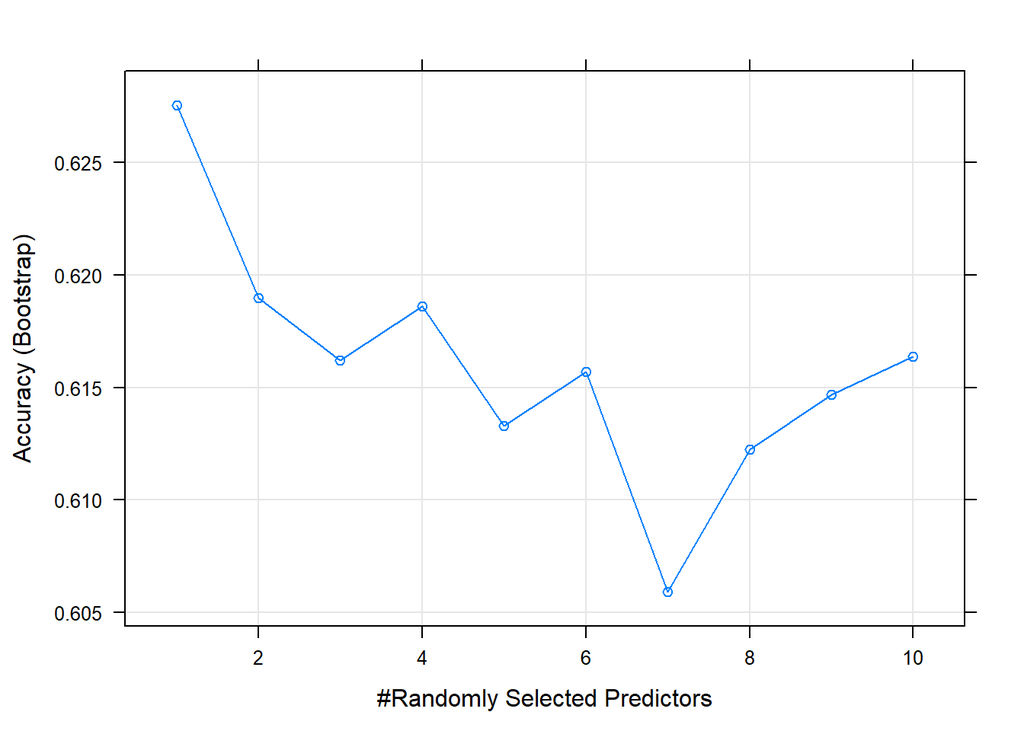

```
## Confusion Matrix and Statistics
##
##           Reference
## Prediction   -1    1
##         -1 1595  918
##         1  1118 1795
##
##                Accuracy : 0.6248
##                  95% CI : (0.6117, 0.6377)
##     No Information Rate : 0.5
##     P-Value [Acc > NIR] : < 2.2e-16
##
##                   Kappa : 0.2495
##
##  Mcnemar's Test P-Value : 1.032e-05
##
##             Sensitivity : 0.5879
##             Specificity : 0.6616
##          Pos Pred Value : 0.6347
##          Neg Pred Value : 0.6162
##              Prevalence : 0.5000
##          Detection Rate : 0.2940
##    Detection Prevalence : 0.4631
##       Balanced Accuracy : 0.6248
##
##        'Positive' Class : -1
##
```

```
## Generalized Linear Model
##
## 11755 samples, 5821 used for final model
##    10 predictor
##     2 classes: '-1', '1'
##
## No pre-processing
## Resampling: Bootstrapped (1 reps)
## Summary of sample sizes: 5934
## Resampling results:
##
##   Accuracy  Kappa
##   0.640268  0.2805372
```

```
## Confusion Matrix and Statistics
##
##           Reference
## Prediction   -1    1
##         -1 1722  974
##         1   991 1739
##
##                Accuracy : 0.6379
##                  95% CI : (0.6249, 0.6507)
##     No Information Rate : 0.5
##     P-Value [Acc > NIR] : <2e-16
##
##                   Kappa : 0.2757
##
##  Mcnemar's Test P-Value : 0.7181
##
##             Sensitivity : 0.6347
##             Specificity : 0.6410
##          Pos Pred Value : 0.6387
##          Neg Pred Value : 0.6370
##              Prevalence : 0.5000
##          Detection Rate : 0.3174
##    Detection Prevalence : 0.4969
##       Balanced Accuracy : 0.6379
##
##        'Positive' Class : -1
##
```

```
## Support Vector Machines with Linear Kernel
##
## 11755 samples, 5821 used for final model
##    10 predictor
##     2 classes: '-1', '1'
##
## Pre-processing: centered (10), scaled (10)
## Resampling: Bootstrapped (1 reps)
## Summary of sample sizes: 5934
## Resampling results across tuning parameters:
##
##   C      Accuracy   Kappa
##   0.100  0.6354578  0.2709158
##   0.575  0.6352860  0.2705722
##   1.050  0.6358014  0.2716030
##   1.525  0.6356296  0.2712595
##   2.000  0.6356296  0.2712593
##
## Accuracy was used to select the optimal model using the largest value.
## The final value used for the model was C = 1.05.
```

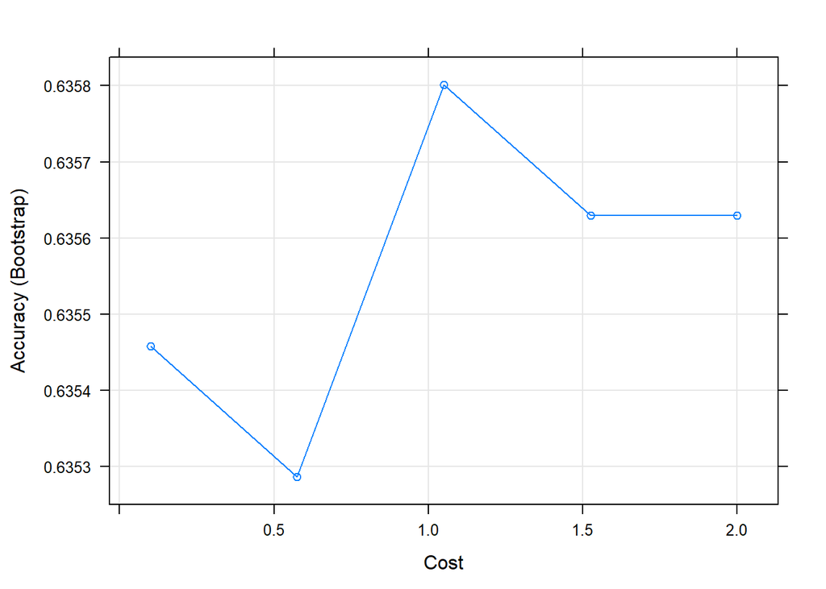

```
## Confusion Matrix and Statistics
##
##           Reference
## Prediction   -1    1
##         -1 1694  966
##         1  1019 1747
##
##                Accuracy : 0.6342
##                  95% CI : (0.6212, 0.647)
##     No Information Rate : 0.5
##     P-Value [Acc > NIR] : <2e-16
##
##                   Kappa : 0.2683
##
##  Mcnemar's Test P-Value : 0.2432
##
##             Sensitivity : 0.6244
##             Specificity : 0.6439
##          Pos Pred Value : 0.6368
##          Neg Pred Value : 0.6316
##              Prevalence : 0.5000
##          Detection Rate : 0.3122
##    Detection Prevalence : 0.4902
##       Balanced Accuracy : 0.6342
##
##        'Positive' Class : -1
##
```

```
## eXtreme Gradient Boosting
##
## 11755 samples, 5821 used for final model
##    10 predictor
##     2 classes: '-1', '1'
##
## No pre-processing
## Resampling: Bootstrapped (1 reps)
## Summary of sample sizes: 5934
## Resampling results across tuning parameters:
##
##   eta  max_depth  colsample_bytree  subsample  nrounds  Accuracy   Kappa
##   0.3  1          0.6               0.50        50      0.6469679  0.2939419
##   0.3  1          0.6               0.50       100      0.6443910  0.2887879
##   0.3  1          0.6               0.50       150      0.6449064  0.2898139
##   0.3  1          0.6               0.75        50      0.6462807  0.2925639
##   0.3  1          0.6               0.75       100      0.6478268  0.2956561
##   0.3  1          0.6               0.75       150      0.6471397  0.2942842
##   0.3  1          0.6               1.00        50      0.6435320  0.2870666
##   0.3  1          0.6               1.00       100      0.6438756  0.2877547
##   0.3  1          0.6               1.00       150      0.6431885  0.2863796
##   0.3  1          0.8               0.50        50      0.6483422  0.2966854
##   0.3  1          0.8               0.50       100      0.6454217  0.2908456
##   0.3  1          0.8               0.50       150      0.6450782  0.2901605
##   0.3  1          0.8               0.75        50      0.6455935  0.2911893
##   0.3  1          0.8               0.75       100      0.6471397  0.2942817
##   0.3  1          0.8               0.75       150      0.6469679  0.2939380
##   0.3  1          0.8               1.00        50      0.6478268  0.2956578
##   0.3  1          0.8               1.00       100      0.6486858  0.2973743
##   0.3  1          0.8               1.00       150      0.6464525  0.2929076
##   0.3  2          0.6               0.50        50      0.6464525  0.2929084
##   0.3  2          0.6               0.50       100      0.6376911  0.2753864
##   0.3  2          0.6               0.50       150      0.6254939  0.2509918
##   0.3  2          0.6               0.75        50      0.6416423  0.2832857
##   0.3  2          0.6               0.75       100      0.6426731  0.2853486
##   0.3  2          0.6               0.75       150      0.6306477  0.2612960
##   0.3  2          0.6               1.00        50      0.6466243  0.2932472
##   0.3  2          0.6               1.00       100      0.6510909  0.3021828
##   0.3  2          0.6               1.00       150      0.6438756  0.2877545
##   0.3  2          0.8               0.50        50      0.6402680  0.2805353
```

[output cut: 73 more lines]

```
##   0.4  3          0.8               0.50       150      0.6081429  0.2162850
##   0.4  3          0.8               0.75        50      0.6358014  0.2716059
##   0.4  3          0.8               0.75       100      0.6224016  0.2448035
##   0.4  3          0.8               0.75       150      0.6172479  0.2344982
##   0.4  3          0.8               1.00        50      0.6376911  0.2753851
##   0.4  3          0.8               1.00       100      0.6316784  0.2633605
##   0.4  3          0.8               1.00       150      0.6273836  0.2547701
##
## Tuning parameter 'gamma' was held constant at a value of 0
## Tuning
##  parameter 'min_child_weight' was held constant at a value of 1
## Accuracy was used to select the optimal model using the largest value.
## The final values used for the model were nrounds = 100, max_depth = 2, eta
##  = 0.3, gamma = 0, colsample_bytree = 0.6, min_child_weight = 1 and subsample
##  = 1.
```

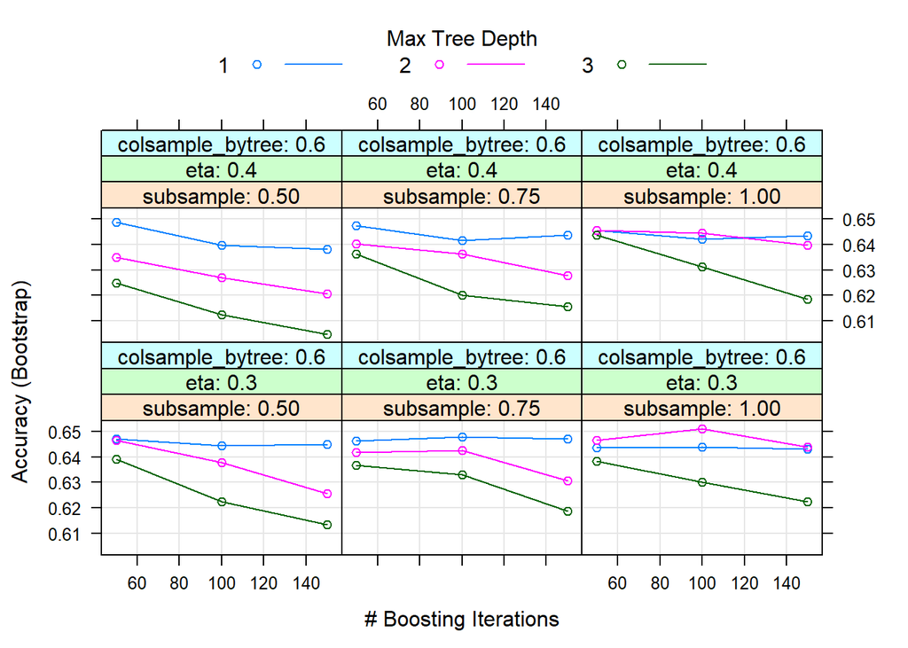

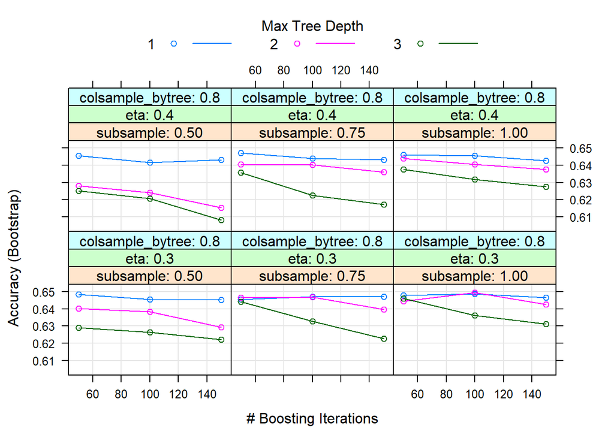

```
## Confusion Matrix and Statistics
##
##           Reference
## Prediction   -1    1
##         -1 1648  919
##         1  1065 1794
##
##                Accuracy : 0.6344
##                  95% CI : (0.6214, 0.6472)
##     No Information Rate : 0.5
##     P-Value [Acc > NIR] : < 2.2e-16
##
##                   Kappa : 0.2687
##
##  Mcnemar's Test P-Value : 0.001133
##
##             Sensitivity : 0.6074
##             Specificity : 0.6613
##          Pos Pred Value : 0.6420
##          Neg Pred Value : 0.6275
##              Prevalence : 0.5000
##          Detection Rate : 0.3037
##    Detection Prevalence : 0.4731
##       Balanced Accuracy : 0.6344
##
##        'Positive' Class : -1
##
```